# kmeans clustering

## A comprehensive report on the kmeans clustering algorithm

- Introduction
- What is kmeans?
- kmeans++
- Some examples
- The algorithm
- Applications
- Image Compression
- Spectral Clustering
- Conclusion

# Introduction

This project broadly consisted of two main parts:

- Implementing the kmeans algorithm from scratch in Python
  - The key takeaways were understanding how to translate pseudocode to actual code, debugging, developing small unit tests to check if the code works.
- Apply the code written for interesting applications
  - Applying the algorithms to real world data is the essence of data science and in this project this was achieved.

# What is kmeans?

kmeans is a popular unsupervised machine learning algorithm used for clustering data into a specified number of clusters.

Data groups which are similar are known as clusters. kmeans algorithm is based on calculating centroids of these clusters and assigning data closest to these centroids to the respective clusters.

In this algorithm, the initial centroids are randomly assigned. With each iteration, the mean of the points of each centroid is computed and the centroids are shifted to the mean. Hence the name "kmeans".

The clusters are iteratively computed until the clusters do not change. This is the stopping point of the algorithm.

# kmeans++

kmeans++ is a variation of the kmeans algorithm in which the centroids are not randomly initialized. In this algorithm, the cluster centroids are chosen in a smarter way.

The crux of this algorithm is to choose the centroids such that they are farthest apart. Essentially, we must be choosing a centroid that has the maximum of the minimum distance to existing centroids.

Once these centroids are chosen according to the kmeans++ algorithm, the process is exactly the same as kmeans to choose the clusters.

# Some examples

Here we will take a look at how the algorithm works for different examples and visualize our results.

```python
# import from kmeans.py
%run kmeans
```

### Simple one feature case

Let's first take a simple example of a 1 feature dataset. Here we have the grades of students and we want to bucket it to 3 clusters. From the clusters formed, we identify that similar grades have been put together and the centroids are indicative of what the three score buckets look like.

```python
grades = [92.65,93.87, 74.06, 86.94, 92.26, 94.46, 92.94, 80.65, 92.86,
          85.94, 91.79, 95.23, 85.37, 87.85, 85.71, 93.03]


k =3

grades = np.array(grades).reshape(-1,1)

centroids, clusters = kmeans(grades , k)

print("centroids: ", centroids)
print("vector sample indices for clusters: ", clusters)
for j in range(k):
    print("vector assignments: ", grades[clusters[j]].reshape(-1,1))
```

```
centroids:  [[77.355     ]
 [86.362     ]
 [93.23222222]]
vector sample indices for clusters:  [[2, 7], [3, 9, 12, 13, 14], [0, 1, 4, 5, 6, 8, 10, 11, 15]]
vector assignments:  [[74.06]
 [80.65]]
vector assignments:  [[86.94]
 [85.94]
 [85.37]
 [87.85]
 [85.71]]
vector assignments:  [[92.65]
 [93.87]
 [92.26]
 [94.46]
 [92.94]
 [92.86]
 [91.79]
 [95.23]
 [93.03]]
```

### Visual example

Now, let's look at a more visual example. We synthesize a data that has 4 main clusters and check whether the kmeans algorithm is able to identify them.

*source for plots : https://jakevdp.github.io/PythonDataScienceHandbook/05.11-k-means.html*

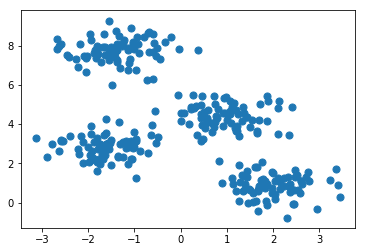

```python
from sklearn.datasets.samples_generator import make_blobs
X, y_true = make_blobs(n_samples=300, centers=4,
                       cluster_std=0.60, random_state=0)
plt.scatter(X[:, 0], X[:, 1], s=50);
```

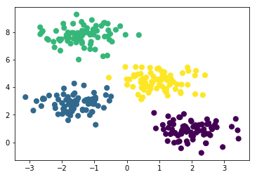

```python
centroids, clusters = kmeans(X,4)
y_kmeans = predict(clusters)

plt.scatter(X[:, 0], X[:, 1], c=y_kmeans, s=50, cmap='viridis')
```

Clearly we can see that kmeans seems to work well for this simple example with 4 well defined clusters.

### Cancer Dataset

Let's now consider a dataset which has more features(30) - the breast cancer dataset from sklearn. This dataset has labels of benign vs cancer and we will now try to cluster the similar records and calculate our accuracy on this using the true labels.

```python
from sklearn.datasets import load_breast_cancer
cancer = load_breast_cancer()
X = cancer.data
Y = cancer.target #y=0 means cancer, y=1 benign

cancer = 0
benign = 1

k = 2

centroids, clusters = kmeans(X , k= k, centroids='kmeans++', tolerance=0.01)
```

Note: We do not actually know what is the predicted class of our clusters since kmeans is an unsupervised algorithm. We choose the mode of the cluster's actual y as prediction for that particular cluster.

```python
likely_confusion_matrix(Y,clusters)
```

```
        pred F  pred T
true F     130      82
true T       1     356
clustering accuracy is:  0.8541300527240774
```

## kmeans ++ vs kmeans - centroids

By creating a sample dataset, we will try both the kmeans and kmeans++ algorithms and visualize how the centroids are chosen differnetly in both.

*source for visualizations:https://towardsdatascience.com/k-means-clustering-with-scikit-learn-6b47a369a83c*

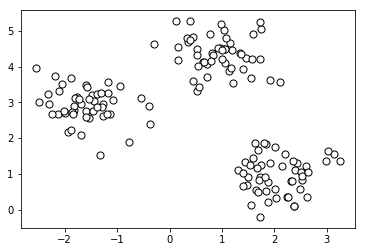

```python
# create dataset
X, y = make_blobs(
   n_samples=150, n_features=2,
   centers=3, cluster_std=0.5,
   shuffle=True, random_state=0
)

# plot
plt.scatter(
   X[:, 0], X[:, 1],
   c='white', marker='o',
   edgecolor='black', s=50
)
plt.show()
```

Above is the data we created and now we will try to apply the kmeans and kmeans++ algorithms and plot the results.

```python
def plot(centroids,y_km):
    # plot the 3 clusters
    plt.scatter(
        X[y_km == 0, 0], X[y_km == 0, 1],
        s=50, c='green',
        marker='s', edgecolor='black',
        label='cluster 1'
    )

    plt.scatter(
        X[y_km == 1, 0], X[y_km == 1, 1],
        s=50, c='yellow',
        marker='o', edgecolor='black',
        label='cluster 2'
    )

    plt.scatter(
        X[y_km == 2, 0], X[y_km == 2, 1],
        s=50, c='blue',
        marker='v', edgecolor='black',
        label='cluster 3'
    )

    # plot the centroids
    plt.scatter(
        centroids[:, 0], centroids[:, 1],
        s=250, marker='*',
        c='red', edgecolor='black',
        label='centroids'
    )
    plt.legend(scatterpoints=1)
    plt.grid()
    plt.show()
```

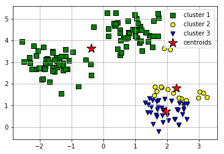

```python
centroids, clusters = kmeans(X,3)
y_km = predict(clusters)
plot(centroids,y_km)
```

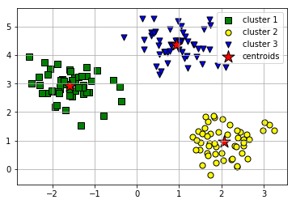

```python
centroids, clusters = kmeans(X,3, centroids='kmeans++')
y_km = predict(clusters)
plot(centroids,y_km)
```

## kmeans ++ vs kmeans - MNIST

```python
from sklearn.datasets import load_digits
digits = load_digits()
X = digits.data
Y = digits.target

k = 10 #since we know there are 10 digits to be clustered
```

```python
centroids, clusters = kmeans(X , k= k, tolerance=0.01)
print ("For kmeans:")
accuracy(Y,clusters)
```

```
For kmeans:
clustering accuracy is:  0.7262103505843072
```

```python
centroids, clusters = kmeans(X , k= k, centroids='kmeans++', tolerance=0.01)
print ("For kmeans++:")
accuracy(Y,clusters)
```

```
For kmeans++:
clustering accuracy is:  0.7907623817473567
```

# The algorithm

These are the steps I followed to implement these algorithms: ( here X is the given data to be clustered and k is the number of clusters) For kmeans:

```
1. For given k, initialize k random centroid points from given X points
2. For each point in X, find the centroid closest to X and assign said point to the cluster
3. With the newly formed clusters, compute the new centroid as a mean of the cluster points for that centroid
4. Iterate until the clusters do not change (centroids remain the same)
```

For kmeans++:

```
1. Pick the first centroid at random.
2. Pick the next centroid such that the minimum distance to the existing cluster centroids is maximized.
3. Iterate to find the next k-1 centroids.
4. The rest of the algorithm is the same as kmeans
```

## How to choose k?

Often we may not know the ideal number of clusters to be selected as the data is unknown and we don't have any idea of the labels or how many groups can exist. In such a scenario we must choose a k-value based on other computational methods.

Optimal value of k can be chosen using the **"elbow method"**. In this method, the squared errors are calculated for each point by computing the distance from a point to the assigned cluster. The overall sum of squares is compared for a set of k values and the k with lowest square errors is chosen as optimal.

Another method to determine k value is using **"silhouette method"** which computes the similaraity between points in same cluster vs other clusters. k value with a high silhoutte score is chosen as optimal k.

# Applications

In the data sciene industry kmeans is widely using for the following:

- Document Classification
- Fraud detection
- Customer Segmentation
- Crime profiling

For any typical data science problem, we can use clustering to create new features to train our model.

Below, we discuss another interesting application which is image compression.

# Image Compression

Here we will use kmeans to compress greyscale and colour images

## Greyscale

```
Original Image:
```

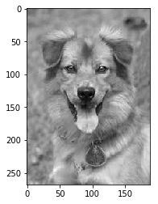

```python
import matplotlib.image as mpimg
img = mpimg.imread('example3.jpeg')
imgplot = plt.imshow(img)
print("Original Image:")
plt.show()
```

```
Compressed Image:
```

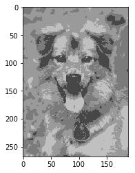

```python
X = img.reshape(-1,1)
k=4
centroids, clusters = kmeans(X, k=k,tolerance=.01)
centroids = centroids.astype(np.uint8)
m = np.zeros(X.shape)
for i,j in enumerate(clusters):
    m[j] = centroids[i]
new = m.reshape(img.shape)
print("Compressed Image:")
imgplot = plt.imshow(new.astype('uint8'))
```

With just 4 of the greyscale levels, the above image still looks recognizable after the compression!

## Colour

```
Original Image:
```

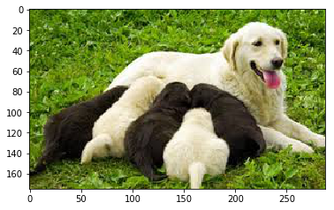

```python
img = mpimg.imread('image1.jpeg')
imgplot = plt.imshow(img)
print("Original Image:")
plt.show()
```

```
Compressed Image:
```

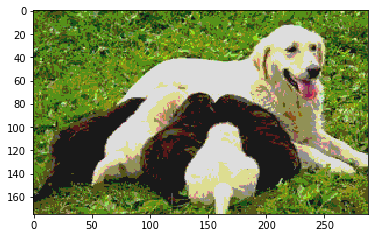

```python
X = img.reshape(-1,1)
k=4
centroids, clusters = kmeans(X, k=k,tolerance=.05)
centroids = centroids.astype(np.uint8)
m = np.zeros(X.shape)
for i,j in enumerate(clusters):
    m[j] = centroids[i]
new = m.reshape(img.shape)
print("Compressed Image:")
imgplot = plt.imshow(new.astype('uint8'))
```

```
Original Image:
```

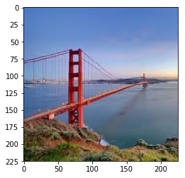

```python
img = mpimg.imread('image4.jpeg')
imgplot = plt.imshow(img)
print("Original Image:")
plt.show()
```

```
Compressed Image:
```

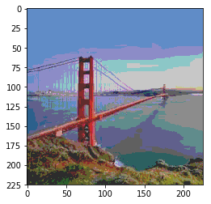

```python
X = img.reshape(-1,1)

k=4
centroids, clusters = kmeans(X, k=k,tolerance=.05)
centroids = centroids.astype(np.uint8)

m = np.zeros(X.shape)
for i,j in enumerate(clusters):
    m[j] = centroids[i]
new = m.reshape(img.shape)

print("Compressed Image:")
imgplot = plt.imshow(new.astype('uint8'))
```

# Spectral Clustering

Another popular clustering algorithm is spectral clustering. It is particulrly useful when the shapes of clusters are not spherical (like in kmeans since it uses the mean to compute the groups)

Spectral clustering involves creating a similarity graph and uses a kmeans model with eigenvectors as inputs.

# Conclusion

From this project I was able to understand the kmeans clustering algorithm and how it can be applied to data science problems. It would be interesting to understand how we can improve clustering techniques and gain a better understanding of evaluating unsupervised machine learning models. Some of things that I was able to answer doing this project were:

- What is kmeens clustering
- How is kmeans++ different from kmeans
- How to implement the algoruthms from scratch
- How to choose k
- Applications to data science
- How to do image compression using kmeans
- What is spectral clustering